# Kravd innlating 3

Innlating í Moodle: seinast um kvøldið 14. mars 2023. Endurbrúka eisini fílnavnið á hesum template-skjalinum, sum tit lata inn, har tit seta tykkara forbókstavir inn fyri NN1_NN2_NN3_NN4.

## Dátuvísindi og hagfrøði við RStudio

### Innleiðing

> Hendan innlating skal skal gerast í RStudio við brúk av R Markdown. Hetta soleiðis, at tú brúkar hugtøkini, sum vit hava lært innan endurskapandi gransking (reproducible research) við RStudio, har tú bindur tín tekst, R-kodu og úrslit saman í eitt html_notebook skjal, sum tú síðani letur inn.

> Hevur tú trupulleikar við at fáa R Markdown at virka, ella bert vilt skilja R Markdown betur, so les meira um evnið í *R for Data Science* lærubókini (**27** R Markdown og **29** R Markdown formats).

> Henda innlatingin er einamest um greining og plot av data við brúk av `tidyverse` hentleikum, sum tit hava lært í *R for Data Science* lærubókini, umframt uppgávur innan simulering, sannlíkindi og sannlíkindafordeilingar, hypotesutestir, sum tit hava lært um úr bókini *Probability, Statistics and Data*.

> Arbeiðið saman - helst bólkar á fýra lesandi - tó undantøk kunna gerast. Tað er sera umráðandi, at hvør einstaklingur í bólkinum er væl við og ger sín part av arbeiðinum. Innlatingin skal vera testað og virka á teldunum hjá hvørjum einstøkum limi í bólkinum.

> Tú/tit opna hetta skjal í RStudio, sum ein template til innlatingina, og skriva tykkara R-kodu í teir givnu, men tómu kodublokkarnar.

> Teir spurningar, sum tit skula svara við vanligum teksti ella tølum, skula tit gera við at svara beint undir hvørjum slíkum spurningi, á linju tit byrja við 4 blonkum teknum. Hetta ger at tykkara svar verður innrammað í eini boks, og soleiðis brýtur frá tekstinum í uppgávuni.

```
Svara tekstspurningum á hendan hátt, beint undir hvørjum slíkum spurningi.
```

> Tá tit eru liðug, ger hvør bólkur eitt endaligt “Run All” og síðani “Preview”, sum kann opnast í browsara (og RStudio), og lata inn skjalið: “kravd3_502123_NN1_NN2_NN3_NN4.nb.html”.

### Setup

> Loada brúktar pakkar, set plot-tema v.m., sum givið í fyrsta kodublokki.

### Uppg. 1

> Vit kanna her sannlíkindini fyri at lesandi hava sama føðingardag, tá ikki verður tikið hædd fyri aldri, og vit antaka at 365 møguligir føðingardagar eru í einum ári.

> 1a) ger eina tibble `sama_fdag` við at brúka `crossing(n_lesandi, roynd_nr)`, har `n_lesandi` eru heiltøl `2:10` fyri antal lesandi, og `roynd_nr` eru heiltøl (index) `1:2` fyri royndir (simuleringar). Seinni økja vit talið av lesandi og royndum. Funktiónin `crossing(n_lesandi, roynd_nr)` ger eina tibble innihaldandi allar kombinatiónir av variablunum `n_lesandi` og `roynd_nr`. Útles `sama_fdag`, og eftirkanna at antal rekkjur sær rætt út (tip: hon skal vera ein `18 x 2` tibble).

```r
n_lesandi <- 2:10
roynd_nr <- 1:2

(sama_fdag <- tibble(
  crossing(n_lesandi, roynd_nr))
)
```

| n_lesandi | roynd_nr |
| --- | --- |
| 2 | 1 |
| 2 | 2 |
| 3 | 1 |
| 3 | 2 |
| 4 | 1 |
| 4 | 2 |
| 5 | 1 |
| 5 | 2 |
| 6 | 1 |
| 6 | 2 |

[output cut: 8 more lines]

> 1b) legg variabul `fdag` afturat `sama_fdag` við brúk av `mutate()` og eini eini `map()`-funktión. Soleiðis, at tú fyri hvørt virði av `n_lesandi` ásetur (simulerar) tilvildarligar føðingardagar fyri tey lesandi við brúk av `sample(365, ., replace = TRUE)`. Útles síðani tibble `sama_fdag` umaftur (tip: hon skal vera ein `18 x 3` tibble).

```r
sama_fdag <- mutate(
  sama_fdag,
  fdag = map(n_lesandi, ~ sample(365, ., replace=TRUE)))
sama_fdag
```

| n_lesandi | roynd_nr | fdag |
| --- | --- | --- |
| 2 | 1 |  |
| 2 | 2 |  |
| 3 | 1 |  |
| 3 | 2 |  |
| 4 | 1 |  |
| 4 | 2 |  |
| 5 | 1 |  |
| 5 | 2 |  |
| 6 | 1 |  |
| 6 | 2 |  |

[output cut: 8 more lines]

> 1c) hvør datatypa er variabul `fdag`? í tibble `sama_fdag`? Útles variabul `fdag` soleiðis, at bæði datatypa og innihald sæst.

```r
#Útles datatypu
cat("Datatypan hjá variabul 'fdag':", typeof(sama_fdag$fdag), "\n \n")
```

```
Datatypan hjá variabul 'fdag': list
```

```r
#Útles innihald
cat("Innihald hjá variabul 'fdag': \n")
```

```
Innihald hjá variabul 'fdag':
```

```r
(sama_fdag$fdag)
```

```
[[1]]
[1]   8 268

[[2]]
[1] 309 180

[[3]]
[1]  33 112 135

[[4]]
[1] 127 337 199

[[5]]
[1]  41  36 175 111

[[6]]
[1] 236 161 102  78

[[7]]
[1] 307  88 269  47 188

[[8]]
[1] 277 235  58 364 163

[[9]]
[1] 160 255  38 293 294  81

[[10]]
[1] 249 321 288 294 178 205

[[11]]
[1] 154 231  41  76 234 352  45

[[12]]
[1] 162 115 217 141  40 321 322

[[13]]
[1] 102 303 237 239 157 352   6 363

[[14]]
[1] 236 319 323 183  46 246  43  95

[[15]]
[1] 105 280  20 331  80 221 360 275 343

[[16]]
[1] 364 359 275  75 200  71 261 220 130

[[17]]
 [1] 111 317 259  81 343 156 263  49  22 185

[[18]]
 [1]  50 231 349 204 295 230  82  21 295 350
```

> 1d) legg variabul `nakar_sdag` afturat `sama_fdag` við brúk av `mutate()`, og eini eini logiskari `map()`-funktión. Soleiðis, at tú fyri hvønn simuleraðan `fdag` eftirkannar (`TRUE` ella `FALSE`) um nøkur lesandi hava sama føðingardag. Útles síðani tibble `sama_fdag` umaftur (tip: hon skal vera ein `18 x 4` tibble).

```r
sama_fdag <- mutate(
  sama_fdag,
  nakar_sdag = map_lgl(fdag, ~ any(duplicated(.x))))

sama_fdag
```

| n_lesandi | roynd_nr | fdag | nakar_sdag |
| --- | --- | --- | --- |
| 2 | 1 |  | FALSE |
| 2 | 2 |  | FALSE |
| 3 | 1 |  | FALSE |
| 3 | 2 |  | FALSE |
| 4 | 1 |  | FALSE |
| 4 | 2 |  | FALSE |
| 5 | 1 |  | FALSE |
| 5 | 2 |  | FALSE |
| 6 | 1 |  | FALSE |
| 6 | 2 |  | FALSE |

[output cut: 8 more lines]

> 1e) ger eina nýggja tibble `p_samadag`, har tú við eini pipe av `sama_fdag` bólkað uppá `n_lesandi` útroknar simuleraðu sannlíkindini `p_sdag` fyri at nakar lesandi hevur sama føðingardag. Útles síðani tibble `p_samadag` (tip: tí vit enn ikki hava økt um talið av lesandi, so skal `p_samadag` bert vera ein `9 x 2` tibble har flestu, ella øll, sannlíkindini eru 0).

```r
(p_samadags <- sama_fdag  %>%
  group_by(n_lesandi) %>%
  summarise(p_sdag = mean(nakar_sdag)))
```

| n_lesandi | p_sdag |
| --- | --- |
| 2 | 0.0 |
| 3 | 0.0 |
| 4 | 0.0 |
| 5 | 0.0 |
| 6 | 0.0 |
| 7 | 0.0 |
| 8 | 0.0 |
| 9 | 0.0 |
| 10 | 0.5 |

> 1f)

> 1f1) samla trinini í 1a, 1b, 1d, og 1e í ein samlaðan pipe-setning, goym úrslitið í tibble `p_samadag`. Útles `p_samadag`, og eftirkanna at tú fært sama/líknandi úrslit sum í 1e.

```r
n_lesandi <- 2:10
roynd_nr <- 1:2

p_samadag <- tibble(
  crossing(n_lesandi, roynd_nr)) %>%
  mutate(fdag = map(n_lesandi, ~ sample(365, ., replace = TRUE)),
         nakar_sdag = map_lgl(fdag, ~ any(duplicated(.x)))) %>%
  group_by(n_lesandi) %>%
  summarise(p_sdag = mean(nakar_sdag))

p_samadag
```

| n_lesandi | p_sdag |
| --- | --- |
| 2 | 0.0 |
| 3 | 0.0 |
| 4 | 0.0 |
| 5 | 0.0 |
| 6 | 0.0 |
| 7 | 0.0 |
| 8 | 0.0 |
| 9 | 0.5 |
| 10 | 0.0 |

> 1f2) set nú talið `n_lesandi` upp til `2:50`, og eftirkanna um tú enn fært sama/líknandi úrslit sum í 1e fyri fyrstu 9 rekkjurnar, og hvat tú nú fært afturat í teimum eyka rekkjunum? Greið frá hvat tú eygleiðir (tip: her skalt tú fáa eina `49 x 2` tibble).

```r
n_lesandi <- 2:50
roynd_nr <- 1:2

p_samadag_1f2 <- tibble(
  crossing(n_lesandi, roynd_nr)) %>%
  mutate(fdag = map(n_lesandi, ~ sample(365, ., replace = TRUE)),
         nakar_sdag = map_lgl(fdag, ~ any(duplicated(.x)))) %>%
  group_by(n_lesandi) %>%
  summarise(p_sdag = mean(nakar_sdag))

p_samadag_1f2
```

| n_lesandi | p_sdag |
| --- | --- |
| 2 | 0.0 |
| 3 | 0.0 |
| 4 | 0.0 |
| 5 | 0.0 |
| 6 | 0.0 |
| 7 | 0.0 |
| 8 | 0.0 |
| 9 | 0.5 |
| 10 | 0.0 |
| 11 | 0.0 |

[output cut: 39 more lines]

```
GREIÐ FRÁ HVAT TAÐ MERKIR
Í fyrstu 9 rekkinum síggja vit ikki stóran mun tá vit hava sama stødd av sampling tvs nummar av namingum so hetta líkist nógv 1.e
men hesari tibble síggja vit at størri okkara sampling er tvs antal av lesandi so síggja vit at sanlíkindini økjast at næmingar hava saman føðingardag.
```

> 1f3) her skal talið `n_lesandi` framvegis vera `2:50`, og set nú talið `roynd_nr` upp til `1:5000`. Eftirkanna aftur, um tú enn fært sama/líknandi úrslit sum í 1e fyri fyrstu 9 rekkjurnar, og hvat tú nú fært í hinum rekkjunum? Greið frá hvat tú eygleiðir (tip: her skalt tú framvegis fáa eina `49 x 2` tibble).

```r
n_lesandi <- 2:50
roynd_nr <- 1:5000

p_samadag <- tibble(
  crossing(n_lesandi, roynd_nr)) %>%
  mutate(fdag = map(n_lesandi, ~ sample(365, ., replace = TRUE)),
         nakar_sdag = map_lgl(fdag, ~ any(duplicated(.x)))) %>%
  group_by(n_lesandi) %>%
  summarise(p_sdag = mean(nakar_sdag))

p_samadag
```

| n_lesandi | p_sdag |
| --- | --- |
| 2 | 0.0018 |
| 3 | 0.0102 |
| 4 | 0.0150 |
| 5 | 0.0250 |
| 6 | 0.0426 |
| 7 | 0.0566 |
| 8 | 0.0794 |
| 9 | 0.0946 |
| 10 | 0.1142 |
| 11 | 0.1392 |

[output cut: 39 more lines]

```
GREIÐ FRÁ!
 Við at økja vit talið av royndum fáa vit fleiri bólkar við sama talið av lesandi, tvs vit nógv meira data at samanberða við, og harvið fáa meria nágreinuligt sanlíkindi.
```

> 1f4) plotta eitt punkt- og linjuplot av `p_samadag` frá spurningi 1f3, har tú mappar `x = n_lesandi` og `y = p_sdag`. Brúka til dømis tilhoyrandi aksa-tekstirnar: “Antal lesandi” og “Sannlíkindini fyri sama føðingardag”. Hvussu stóran flokk av lesandi skalt tú hava fyri at sannlíkindini fyri at nakar í flokkinum hevur sama føðingardag er ávikavist 0.5, 0.7 og 0.9?

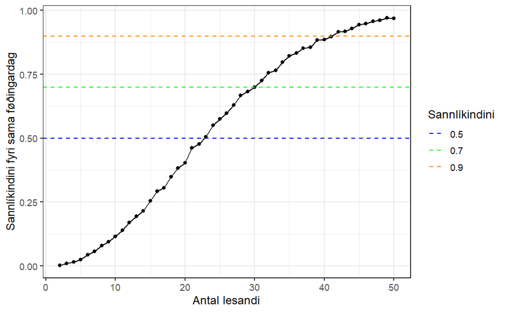

```r
ggplot(p_samadag, aes(x = n_lesandi, y = p_sdag)) +
  geom_point() +
  geom_line() +
  labs(x = "Antal lesandi", y = "Sannlíkindini fyri sama føðingardag")+
  geom_hline(aes(yintercept=0.5, linetype = "0.5"), color = "blue") +
  geom_hline(aes(yintercept=0.7, linetype = "0.7"), color = "green") +
  geom_hline(aes(yintercept=0.9, linetype = "0.9"), color = "darkorange") +
  scale_linetype_manual(name ="Sannlíkindini", values = c('dashed','dashed','dashed'),
                        guide = guide_legend(override.aes = list(color = c("blue", "green", "darkorange"))))
```

```
Sannlíkindini fyri at nakar í flokkinum hevur sama føðingardag er ávikavist:
0.5 er uml. 23
0.7 er uml. 30
0.9 er uml. 41
```

### Uppg. 2

> 2a) legg variablar `n_ymisk`, `n_total`, og `p_teori` afturat tibble `p_samadag`, har tú útroknar teoretisku sannlíkindini `p_teori` fyri at nakar hevur sama føðingardag fyri hvørt virði av `n_lesandi`, og útles síðani `p_samadag` (tip: tað er lættast við formlum frá teljilæru (teljitrupuleikum) at finna sannlíkindini fyri at eingin hevur sama føðingardag, og síðani at draga hesi sannlíkindi frá 1: `p_teori = 1 - n_ymisk/n_total`. Tú kanst til dømis brúka eina `map_dbl()` funktión saman við `prod()` funktiónini í útrokningini av `n_ymisk`). Hvussu væl samsvara tíni simuleraðu `p_sdag` við tíni teoretisku `p_teori`?

```r
p_samadag <- p_samadag %>%
  mutate(n_ymisk = map(n_lesandi, ~prod(365:(365 - . + 1))) %>% unlist,
         n_total = 365^n_lesandi,
         p_teori = 1 - (n_ymisk/n_total)
  )
p_samadag
```

| n_lesandi | p_sdag | n_ymisk | n_total | p_teori |
| --- | --- | --- | --- | --- |
| 2 | 0.0018 | 1.328600e+05 | 1.332250e+05 | 0.002739726 |
| 3 | 0.0102 | 4.822818e+07 | 4.862713e+07 | 0.008204166 |
| 4 | 0.0150 | 1.745860e+10 | 1.774890e+10 | 0.016355912 |
| 5 | 0.0250 | 6.302555e+12 | 6.478349e+12 | 0.027135574 |
| 6 | 0.0426 | 2.268920e+15 | 2.364597e+15 | 0.040462484 |
| 7 | 0.0566 | 8.145422e+17 | 8.630780e+17 | 0.056235703 |
| 8 | 0.0794 | 2.916061e+20 | 3.150235e+20 | 0.074335292 |
| 9 | 0.0946 | 1.041034e+23 | 1.149836e+23 | 0.094623834 |
| 10 | 0.1142 | 3.706080e+25 | 4.196900e+25 | 0.116948178 |
| 11 | 0.1392 | 1.315659e+28 | 1.531869e+28 | 0.141141378 |

[output cut: 39 more lines]

```r
NA
```

> 2b) í R finst eisini ein funktión nevnd `pbirthday()` til útrokning av somu teoretisku sannlíkindunum, sum vit útroknaðu í `p_teori` í 2a omanfyri. Legg ein variabul `p_bday` afturat tibble `p_samadag` við brúk av `pbirthday()` funktiónini og eini `map_dbl()` funktión. Útles síðani tibble `p_samadag` umaftur. Hvussu væl samsvara tíni `p_bday` við tíni `p_teori`?

```r
p_samadag <- mutate(
  p_samadag,
  p_bday = map_dbl(n_lesandi, pbirthday))

p_samadag
```

| n_lesandi | p_sdag | n_ymisk | n_total | p_teori | p_bday |
| --- | --- | --- | --- | --- | --- |
| 2 | 0.0018 | 1.328600e+05 | 1.332250e+05 | 0.002739726 | 0.002739726 |
| 3 | 0.0102 | 4.822818e+07 | 4.862713e+07 | 0.008204166 | 0.008204166 |
| 4 | 0.0150 | 1.745860e+10 | 1.774890e+10 | 0.016355912 | 0.016355912 |
| 5 | 0.0250 | 6.302555e+12 | 6.478349e+12 | 0.027135574 | 0.027135574 |
| 6 | 0.0426 | 2.268920e+15 | 2.364597e+15 | 0.040462484 | 0.040462484 |
| 7 | 0.0566 | 8.145422e+17 | 8.630780e+17 | 0.056235703 | 0.056235703 |
| 8 | 0.0794 | 2.916061e+20 | 3.150235e+20 | 0.074335292 | 0.074335292 |
| 9 | 0.0946 | 1.041034e+23 | 1.149836e+23 | 0.094623834 | 0.094623834 |
| 10 | 0.1142 | 3.706080e+25 | 4.196900e+25 | 0.116948178 | 0.116948178 |
| 11 | 0.1392 | 1.315659e+28 | 1.531869e+28 | 0.141141378 | 0.141141378 |

[output cut: 39 more lines]

```r
NA
```

```
`p_bday` og `p_teori` eru eins
```

> 2c) plotta eitt punkt-plot av `p_samadag` frá spurningi 2b, har tú mappar `x = n_lesandi` og `y = p_sdag`, og har tú hesuferð plottar eina linju fyri tey teoretisku sannlíkindini `p_bday`. Útfrá teoretisku sannlíkindunum í `p_bday`, hvussu stóran flokk av lesandi skalt tú hava fyri at sannlíkindini fyri at nakar í flokkinum hevur sama føðingardag er ávikavist 0.5, 0.7 og 0.9? (tip: avles talvuna, kurvuna og/ella brúka `qbirthday()`-funktiónina).

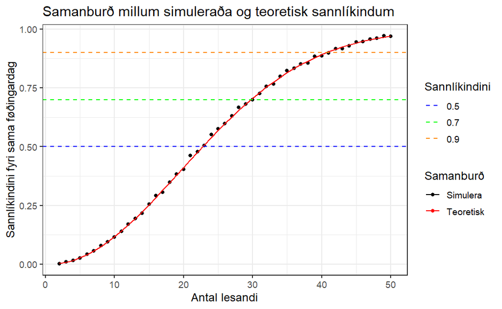

```r
ggplot(p_samadag, aes(x = n_lesandi, y = p_sdag)) +
  geom_point(aes(color = "Simulera")) +
  geom_line(aes(y = p_bday, color = "Teoretisk")) +
  labs(x = "Antal lesandi",
       y = "Sannlíkindini fyri sama føðingardag",
       title = "Samanburð millum simuleraða og teoretisk sannlíkindum")+
  scale_color_manual(name = "Samanburð", values = c("Simulera" = "black", "Teoretisk" = "red"))+

geom_hline(aes(yintercept=0.5, linetype = "0.5"), color = "blue") +
  geom_hline(aes(yintercept=0.7, linetype = "0.7"), color = "green") +
  geom_hline(aes(yintercept=0.9, linetype = "0.9"), color = "darkorange") +
  scale_linetype_manual(name ="Sannlíkindini", values = c('dashed','dashed','dashed'),
                        guide = guide_legend(override.aes = list(color = c("blue", "green", "darkorange"))))
```

```r
(qbirthday(0.5, 365, 2))
```

```
[1] 23
```

```r
(qbirthday(0.7, 365, 2))
```

```
[1] 30
```

```r
(qbirthday(0.9, 365, 2))
```

```
[1] 41
```

```
Við at avlesa talvuna og við brúk av qbirthday, síggja vit at sannlíkindini fyri at nakar í flokkinum hevur sama føðingardag er ávikavist:
0.5 = 23
0.7 = 30
0.9 = 41
```

> 2d) hvørji eru sannlíkindini útroknaði við `pbirthday()` fyri at minst tvey hava sama føðingardag, tá `n_lesandi = 50`, og tá `n_lesandi = 80`?

```r
(pbirthday(50, 365, 2))
```

```
[1] 0.9703736
```

```r
(pbirthday(80, 365, 2))
```

```
[1] 0.9999143
```

```
Tá n_lesandi = 50, er tað 97% sannlíkindini fyri at minst tvey hava sama føðingardag.
Tá n_lesandi = 80, er tað næstan 100% sannlíkindini fyri at minst tvey hava sama føðingardag.
```

> 2e) higartil hava vit bert kannað tey føri har minst tvey hava sama føðingardag (`TRUE` ella `FALSE` fyri at nakar lesandi hevur sama føðingardag), men vit hava ikki kannað hvussu nógv tey eru, sum hava sama føðingardag. Vit generalisera nú føðingardags-spurningin til eisini at umfata talið á teimum, sum hava sama føðingardag. Neyvari lýst, so finna vit støddina `max_sdag` á tí størsta bólkinum við sama føðingardegi í einum flokki av `n_lesandi`. Ímeðan vit byggja greiningina upp, brúka vit til dømis tølini `n_lesandi = seq(5, 700, 5)` og `roynd_nr = 1:100`, sum vit síðani kunna broyta, tá kodan virkar.

> 2e1) vit skula tí í einum broyttum pipe-setningi frá `crossing(n_lesandi = seq(5, 700, 5), roynd_nr = 1:100)`, sum skapar eina tibble `p_maxsdag`, gera ein variabul `max_sdag`. Hetta gera vit við brúk av eini `map_int()` funktión, saman við `table()` og `max()` funktiónunum. Somuleiðis, broyta vit heitið á `nakar_sdag` til `>= 2`, og vit gera eisini variablar `== 2`, `== 3`, `== 4` og `== 5`, har vit kanna um `max_sdag == 2`, `max_sdag == 3` o.s.f. Útles `p_maxsdag`, tá hetta er gjørt (tip: við `n_lesandi = seq(5, 700, 5)` og `roynd_nr = 1:100` gevur hetta eina tibble á `14000 x 9` við `14000` rekkjum og `9` variablum: `n_lesandi, roynd_nr, fdag, >= 2, max_sdag, == 2, == 3, == 4, == 5`).

```r
n_lesandi = seq(5, 700, 5)
roynd_nr = 1:100

p_maxsdag <- crossing(n_lesandi, roynd_nr) %>%
  mutate(
    fdag = map(n_lesandi, ~sample(365, ., replace = TRUE)),
    `>= 2` = map_int(fdag, ~any(duplicated(.x))),
    max_sdag = map_int(fdag, function(x) max(table(x))),
    `== 2` = max_sdag == 2,
    `== 3` = max_sdag == 3,
    `== 4` = max_sdag == 4,
    `== 5` = max_sdag == 5,
  )

p_maxsdag
```

| n_lesandi | roynd_nr | fdag | >= 2 | max_sdag | == 2 | == 3 | == 4 | == 5 |
| --- | --- | --- | --- | --- | --- | --- | --- | --- |
| 5 | 1 |  | 0 | 1 | FALSE | FALSE | FALSE | FALSE |
| 5 | 2 |  | 0 | 1 | FALSE | FALSE | FALSE | FALSE |
| 5 | 3 |  | 0 | 1 | FALSE | FALSE | FALSE | FALSE |
| 5 | 4 |  | 0 | 1 | FALSE | FALSE | FALSE | FALSE |
| 5 | 5 |  | 0 | 1 | FALSE | FALSE | FALSE | FALSE |
| 5 | 6 |  | 0 | 1 | FALSE | FALSE | FALSE | FALSE |
| 5 | 7 |  | 0 | 1 | FALSE | FALSE | FALSE | FALSE |
| 5 | 8 |  | 0 | 1 | FALSE | FALSE | FALSE | FALSE |
| 5 | 9 |  | 0 | 1 | FALSE | FALSE | FALSE | FALSE |
| 5 | 10 |  | 0 | 1 | FALSE | FALSE | FALSE | FALSE |

[output cut: 990 more lines]

```r
NA
```

> 2e2) vit byggja víðari uppá pipe-setningin við `pivot_longer()` og samla allar logisku variablarnar `>= 2`, `== 2`, `== 3`, `== 4`, `== 5` í eina kolonnu vit nevna `max` og virðini í eina kolonnu vit nevna `sdag`. Útles `p_maxsdag`, tá hetta er gjørt (tip: við `n_lesandi = seq(5, 700, 5)` og `roynd_nr = 1:100` gevur hetta eina tibble á `70000 x 6` við `70000` rekkjum og `6` variablum: `n_lesandi, roynd_nr, fdag, max_sdag, max, sdag`).

```r
p_maxsdag <- p_maxsdag %>%
pivot_longer(
    cols = c(`>= 2`, `== 2`, `== 3`, `== 4`, `== 5`),
    names_to = "max",
    values_to = "sdag"
  )

p_maxsdag
```

| n_lesandi | roynd_nr | fdag | max_sdag | max | sdag |
| --- | --- | --- | --- | --- | --- |
| 5 | 1 |  | 1 | >= 2 | 0 |
| 5 | 1 |  | 1 | == 2 | 0 |
| 5 | 1 |  | 1 | == 3 | 0 |
| 5 | 1 |  | 1 | == 4 | 0 |
| 5 | 1 |  | 1 | == 5 | 0 |
| 5 | 2 |  | 1 | >= 2 | 0 |
| 5 | 2 |  | 1 | == 2 | 0 |
| 5 | 2 |  | 1 | == 3 | 0 |
| 5 | 2 |  | 1 | == 4 | 0 |
| 5 | 2 |  | 1 | == 5 | 0 |

[output cut: 990 more lines]

> 2e3) vit byggja víðari uppá pipe-setningin inn í `group_by(n_lesandi, max)` har tú útroknar sannlíkindini `p_sdag` av `sdag` fyri allar kombinatiónir av `n_lesandi` og `max`. Útles `p_maxsdag`, tá hetta er gjørt (tip: við `n_lesandi = seq(5, 700, 5)` og `roynd_nr = 1:100` gevur hetta eina tibble á `700 x 3` við `700` rekkjum og `3` variablum: `n_lesandi, max, p_sdag`).

```r
p_maxsdag <- p_maxsdag %>%
  group_by(n_lesandi, max) %>%
  summarize(p_sdag = mean(sdag))

p_maxsdag
```

| n_lesandi | max | p_sdag |
| --- | --- | --- |
| 5 | == 2 | 0.01 |
| 5 | == 3 | 0.00 |
| 5 | == 4 | 0.00 |
| 5 | == 5 | 0.00 |
| 5 | >= 2 | 0.01 |
| 10 | == 2 | 0.09 |
| 10 | == 3 | 0.00 |
| 10 | == 4 | 0.00 |
| 10 | == 5 | 0.00 |
| 10 | >= 2 | 0.09 |

[output cut: 690 more lines]

> 2e4) plotta eitt punkt- og linjuplot av `p_maxsdag` frá spurningi 2e3, har tú mappar `x = n_lesandi` og `y = p_sdag`, og har tú hesuferð mappar lit til `max` so tú fært ein legend.

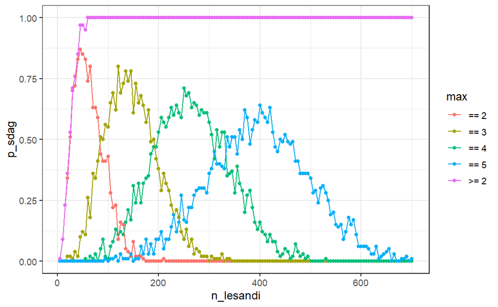

```r
ggplot(p_maxsdag, aes(x = n_lesandi, y = p_sdag, color = max)) +
  geom_point() +
  geom_line()
```

> 2f) vit dagføra nú simuleringina.

> 2f1) dagfør tibble `p_maxsdag` við at endurbrúka kodu frá spurning 2e3, og set til dømis `n_lesandi = c(2, seq(10, 700, 10))` og `roynd_nr = 1:2000`. Útles tína dagførdu `p_maxsdag`.

```r
n_lesandi = c(2, seq(10, 700, 10))
roynd_nr = 1:2000

p_maxsdag <- crossing(n_lesandi, roynd_nr) %>%
  mutate(
    fdag = map(n_lesandi, ~sample(365, ., replace = TRUE)),
    `>= 2` = map_int(fdag, ~any(duplicated(.x))),
    max_sdag = map_int(fdag, function(x) max(table(x))),
    `== 2` = max_sdag == 2,
    `== 3` = max_sdag == 3,
    `== 4` = max_sdag == 4,
    `== 5` = max_sdag == 5,
  ) %>%
  pivot_longer(
    cols = c(`>= 2`, `== 2`, `== 3`, `== 4`, `== 5`),
    names_to = "max",
    values_to = "sdag"
  ) %>%
  group_by(n_lesandi, max) %>%
  summarize(p_sdag = mean(sdag))

p_maxsdag
```

| n_lesandi | max | p_sdag |
| --- | --- | --- |
| 2 | == 2 | 0.0040 |
| 2 | == 3 | 0.0000 |
| 2 | == 4 | 0.0000 |
| 2 | == 5 | 0.0000 |
| 2 | >= 2 | 0.0040 |
| 10 | == 2 | 0.1185 |
| 10 | == 3 | 0.0005 |
| 10 | == 4 | 0.0000 |
| 10 | == 5 | 0.0000 |
| 10 | >= 2 | 0.1190 |

[output cut: 345 more lines]

> 2f2) plotta eitt punkt- og linjuplot av dagførdu `p_maxsdag` frá spurningi 2f1, har tú mappar `x = n_lesandi` og `y = p_sdag`, og har tú aftur mappar lit til `max` so tú fært ein legend.

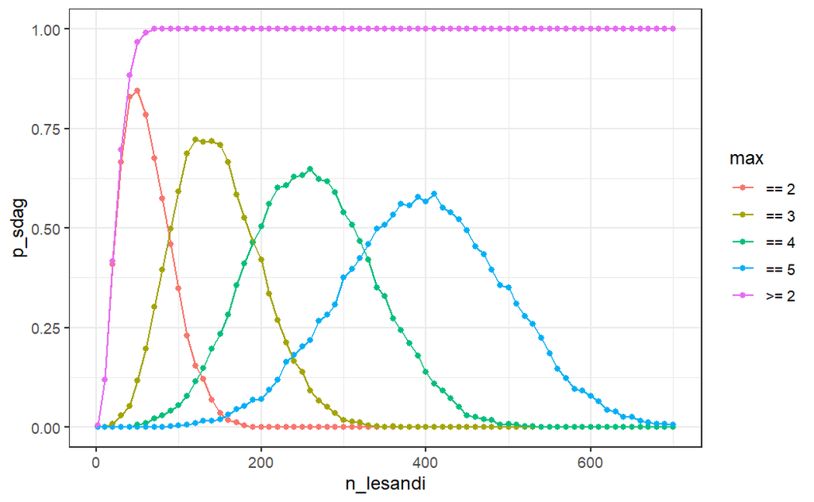

```r
ggplot(p_maxsdag, aes(x = n_lesandi, y = p_sdag, color = max)) +
  geom_point() +
  geom_line()
```

> næstu tveir spurningar eru eins, men kunna svarast í 2f3 við avlesing av plotti og/ella í 2f4 við at gera eina pipe.

> 2f3) um tú hyggur eftir virðunum `50, 100, 200, 300, 400` fyri antal lesandi, hvørji sannlíkindi `p_sdag` fyri `max == 2, 3, 4, 5` eru ávikavist hægst, næst- og trið-hægst í hvørjum føri? (tip: avles plottið í 2f2).

> 2f4) um tú hyggur eftir virðunum `50, 100, 200, 300, 400` fyri antal lesandi, hvørji sannlíkindi `p_sdag` fyri `max == 2, 3, 4, 5` eru ávikavist hægst, næst- og trið-hægst í hvørjum føri? (tip: ger ein pipe-setning av `p_maxsdag`, sum einans vísir rekkjur fyri `n_lesandi` í `50, 100, 200, 300, 400` sorteraðar eftir vaksandi `n_lesandi` og fallandi `p_sdag`. Legg síðani ein variabul `nr` afturat tíni tibble við brúk av `row_number()`, sum tú filtrerar at vera `nr <= 3`. Úrslitið skal hava `15` rekkjur og `4` variablar: `n_lesandi, max, p_sdag, nr`, har `nr` inniheldur virðini `1, 2, 3`).

```r
p_maxsdag_filtered <- p_maxsdag %>%
  filter(n_lesandi %in% c(50, 100, 200, 300, 400)) %>%
  arrange(n_lesandi, desc(p_sdag)) %>%
  mutate(nr = row_number()) %>%
  filter(nr <= 3)

p_maxsdag_filtered
```

| n_lesandi | max | p_sdag | nr |
| --- | --- | --- | --- |
| 50 | >= 2 | 0.9675 | 1 |
| 50 | == 2 | 0.8450 | 2 |
| 50 | == 3 | 0.1170 | 3 |
| 100 | >= 2 | 1.0000 | 1 |
| 100 | == 3 | 0.5925 | 2 |
| 100 | == 2 | 0.3490 | 3 |
| 200 | >= 2 | 1.0000 | 1 |
| 200 | == 4 | 0.5050 | 2 |
| 200 | == 3 | 0.4200 | 3 |
| 300 | >= 2 | 1.0000 | 1 |

[output cut: 5 more lines]

```r
NA
```

### Uppg. 3

> 3a) les givnu fíluna `ferdslu_ohapp.csv` inn í tibble `ferdslu_ohapp` við einføldum brúki av `read_csv()`-funktiónini uttan nakrar parametrar (tip: tú fært eina `25 x 1` tibble).

```r
ferdslu_ohapp <- read_csv("ferdslu_ohapp.csv")
ferdslu_ohapp
```

| SS03060 Ferðsluóhapp skift á sýslu, stað og slag (1995-2017) |
| --- |
| sýsla,stað,slag,1995,1996,1997,1998,1999,2000,2001,2002,2003,2004,2005,2006,2007,2008,2009,2010,2011,2012 |
| Norðoya sýsla,Á landsvegi,Ferðsluóhapp tilsamans,22,17,22,33,29,34,32,28,16,31,37,43,22,24,..,19,18,13 |
| Norðoya sýsla,Á landsvegi,Skadd fólk,1,2,2,1,6,1,3,-,1,1,1,8,4,1,..,1,2,- |
| Norðoya sýsla,Á kommunalvegi,Ferðsluóhapp tilsamans,122,119,122,133,138,130,147,139,130,134,123,107,109,78,..,51,73,49 |
| Norðoya sýsla,Á kommunalvegi,Skadd fólk,9,5,8,3,4,7,6,8,3,7,8,5,2,4,..,-,-,- |
| Eysturoyar sýsla,Á landsvegi,Ferðsluóhapp tilsamans,115,87,97,107,116,119,97,99,101,106,126,82,105,121,..,78,87,60 |
| Eysturoyar sýsla,Á landsvegi,Skadd fólk,9,9,17,13,8,13,13,12,24,15,6,13,15,9,..,8,4,4 |
| Eysturoyar sýsla,Á kommunalvegi,Ferðsluóhapp tilsamans,98,95,119,140,119,133,133,124,109,111,104,124,95,82,..,69,53,47 |
| Eysturoyar sýsla,Á kommunalvegi,Skadd fólk,6,8,12,6,5,8,10,5,7,2,2,3,3,2,..,6,2,- |
| Streymoyar sýsla,Á landsvegi,Ferðsluóhapp tilsamans,115,117,91,126,157,131,141,136,123,147,139,154,124,132,..,117,92,79 |

[output cut: 15 more lines]

```r
NA
```

> 3b) les umaftur givnu fíluna `ferdslu_ohapp.csv` inn í tibble `ferdslu_ohapp` við `read_csv()`-funktiónini, men nú við brúk av parametrum. Soleiðis, at data verða innlisin uttan fyrstu linju av metadata, og har tómu virðini merkt við `..` vera sett til `NA` virði. Útles síðani `ferdslu_ohapp` umaftur (tip: tú fært eina `24 x 21` tibble).

```r
(ferdslu_ohapp <- read_csv("ferdslu_ohapp.csv", show_col_types = FALSE, skip = 1, na = c("..", NA)))
```

| sýsla | stað | slag | 1995 | 1996 | 1997 | 1998 | 1999 | 2000 | 2001 | 2002 | 2003 | 2004 | 2005 | 2006 | 2007 | 2008 | 2009 | 2010 | 2011 | 2012 |
| --- | --- | --- | --- | --- | --- | --- | --- | --- | --- | --- | --- | --- | --- | --- | --- | --- | --- | --- | --- | --- |
| Norðoya sýsla | Á landsvegi | Ferðsluóhapp tilsamans | 22 | 17 | 22 | 33 | 29 | 34 | 32 | 28 | 16 | 31 | 37 | 43 | 22 | 24 | NA | 19 | 18 | 13 |
| Norðoya sýsla | Á landsvegi | Skadd fólk | 1 | 2 | 2 | 1 | 6 | 1 | 3 | - | 1 | 1 | 1 | 8 | 4 | 1 | NA | 1 | 2 | - |
| Norðoya sýsla | Á kommunalvegi | Ferðsluóhapp tilsamans | 122 | 119 | 122 | 133 | 138 | 130 | 147 | 139 | 130 | 134 | 123 | 107 | 109 | 78 | NA | 51 | 73 | 49 |
| Norðoya sýsla | Á kommunalvegi | Skadd fólk | 9 | 5 | 8 | 3 | 4 | 7 | 6 | 8 | 3 | 7 | 8 | 5 | 2 | 4 | NA | - | - | - |
| Eysturoyar sýsla | Á landsvegi | Ferðsluóhapp tilsamans | 115 | 87 | 97 | 107 | 116 | 119 | 97 | 99 | 101 | 106 | 126 | 82 | 105 | 121 | NA | 78 | 87 | 60 |
| Eysturoyar sýsla | Á landsvegi | Skadd fólk | 9 | 9 | 17 | 13 | 8 | 13 | 13 | 12 | 24 | 15 | 6 | 13 | 15 | 9 | NA | 8 | 4 | 4 |
| Eysturoyar sýsla | Á kommunalvegi | Ferðsluóhapp tilsamans | 98 | 95 | 119 | 140 | 119 | 133 | 133 | 124 | 109 | 111 | 104 | 124 | 95 | 82 | NA | 69 | 53 | 47 |
| Eysturoyar sýsla | Á kommunalvegi | Skadd fólk | 6 | 8 | 12 | 6 | 5 | 8 | 10 | 5 | 7 | 2 | 2 | 3 | 3 | 2 | NA | 6 | 2 | - |
| Streymoyar sýsla | Á landsvegi | Ferðsluóhapp tilsamans | 115 | 117 | 91 | 126 | 157 | 131 | 141 | 136 | 123 | 147 | 139 | 154 | 124 | 132 | NA | 117 | 92 | 79 |
| Streymoyar sýsla | Á landsvegi | Skadd fólk | 11 | 17 | 17 | 18 | 11 | 4 | 34 | 19 | 21 | 12 | 12 | 25 | 14 | 28 | NA | 21 | 5 | 23 |

[output cut: 14 more lines]

> 3c) snøgga tibble `ferdslu_ohapp` í fylgjandi trinum:

> 3c1) broyt øll virðini í `ferdslu_ohapp` merkt sum ‘-’ til ‘0’ og les hana útaftur (tip: hetta kann lættast gerast við eini pipe av `ferdslu_ohapp` inn í `mutate(across())`, har tit lata `across()` kalla eina `str_replace` funktión).

```r
ferdslu_ohapp <- ferdslu_ohapp %>%
  mutate(across(c(4:21),
  .fns = ~str_to_lower(str_replace_all(.,"-", "0"))))

ferdslu_ohapp
```

| sýsla | stað | slag | 1995 | 1996 | 1997 | 1998 | 1999 | 2000 | 2001 | 2002 | 2003 | 2004 | 2005 | 2006 | 2007 | 2008 | 2009 | 2010 | 2011 | 2012 |
| --- | --- | --- | --- | --- | --- | --- | --- | --- | --- | --- | --- | --- | --- | --- | --- | --- | --- | --- | --- | --- |
| Norðoya sýsla | Á landsvegi | Ferðsluóhapp tilsamans | 22 | 17 | 22 | 33 | 29 | 34 | 32 | 28 | 16 | 31 | 37 | 43 | 22 | 24 | NA | 19 | 18 | 13 |
| Norðoya sýsla | Á landsvegi | Skadd fólk | 1 | 2 | 2 | 1 | 6 | 1 | 3 | 0 | 1 | 1 | 1 | 8 | 4 | 1 | NA | 1 | 2 | 0 |
| Norðoya sýsla | Á kommunalvegi | Ferðsluóhapp tilsamans | 122 | 119 | 122 | 133 | 138 | 130 | 147 | 139 | 130 | 134 | 123 | 107 | 109 | 78 | NA | 51 | 73 | 49 |
| Norðoya sýsla | Á kommunalvegi | Skadd fólk | 9 | 5 | 8 | 3 | 4 | 7 | 6 | 8 | 3 | 7 | 8 | 5 | 2 | 4 | NA | 0 | 0 | 0 |
| Eysturoyar sýsla | Á landsvegi | Ferðsluóhapp tilsamans | 115 | 87 | 97 | 107 | 116 | 119 | 97 | 99 | 101 | 106 | 126 | 82 | 105 | 121 | NA | 78 | 87 | 60 |
| Eysturoyar sýsla | Á landsvegi | Skadd fólk | 9 | 9 | 17 | 13 | 8 | 13 | 13 | 12 | 24 | 15 | 6 | 13 | 15 | 9 | NA | 8 | 4 | 4 |
| Eysturoyar sýsla | Á kommunalvegi | Ferðsluóhapp tilsamans | 98 | 95 | 119 | 140 | 119 | 133 | 133 | 124 | 109 | 111 | 104 | 124 | 95 | 82 | NA | 69 | 53 | 47 |
| Eysturoyar sýsla | Á kommunalvegi | Skadd fólk | 6 | 8 | 12 | 6 | 5 | 8 | 10 | 5 | 7 | 2 | 2 | 3 | 3 | 2 | NA | 6 | 2 | 0 |
| Streymoyar sýsla | Á landsvegi | Ferðsluóhapp tilsamans | 115 | 117 | 91 | 126 | 157 | 131 | 141 | 136 | 123 | 147 | 139 | 154 | 124 | 132 | NA | 117 | 92 | 79 |
| Streymoyar sýsla | Á landsvegi | Skadd fólk | 11 | 17 | 17 | 18 | 11 | 4 | 34 | 19 | 21 | 12 | 12 | 25 | 14 | 28 | NA | 21 | 5 | 23 |

[output cut: 14 more lines]

> 3c2) samla øll árini í `ferdslu_ohapp` í ein nýggjan variabul `ár` og virðini í ein nýggjan variabul `n`, og útles `ferdslu_ohapp` (tip: tú fært eina `432 x 5` tibble. Um títt `n` ikki er numeriskt, broyt so `n` til integer og útles `ferdslu_ohapp` umaftur, áðrenn tú fert víðari).

```r
ferdslu_ohapp <- ferdslu_ohapp %>% mutate(across(c(4:21), as.integer))

ferdslu_ohapp <- ferdslu_ohapp %>%
  pivot_longer(
    cols = c(4:21),
    names_to = "ár",
    values_to = "n"
  )

ferdslu_ohapp
```

| sýsla | stað | slag | ár | n |
| --- | --- | --- | --- | --- |
| Norðoya sýsla | Á landsvegi | Ferðsluóhapp tilsamans | 1995 | 22 |
| Norðoya sýsla | Á landsvegi | Ferðsluóhapp tilsamans | 1996 | 17 |
| Norðoya sýsla | Á landsvegi | Ferðsluóhapp tilsamans | 1997 | 22 |
| Norðoya sýsla | Á landsvegi | Ferðsluóhapp tilsamans | 1998 | 33 |
| Norðoya sýsla | Á landsvegi | Ferðsluóhapp tilsamans | 1999 | 29 |
| Norðoya sýsla | Á landsvegi | Ferðsluóhapp tilsamans | 2000 | 34 |
| Norðoya sýsla | Á landsvegi | Ferðsluóhapp tilsamans | 2001 | 32 |
| Norðoya sýsla | Á landsvegi | Ferðsluóhapp tilsamans | 2002 | 28 |
| Norðoya sýsla | Á landsvegi | Ferðsluóhapp tilsamans | 2003 | 16 |
| Norðoya sýsla | Á landsvegi | Ferðsluóhapp tilsamans | 2004 | 31 |

[output cut: 422 more lines]

> 3c3) deil variabul `slag` í tveir nýggjar variablar við heitum frá `slag` og virðum frá `n`, og útles `ferdslu_ohapp` umaftur (tip: tú fært eina `216 x 5` tibble).

```r
ferdslu_ohapp <- ferdslu_ohapp %>%
  pivot_wider(names_from = c(slag), values_from = c(n))

ferdslu_ohapp
```

| sýsla | stað | ár | Ferðsluóhapp tilsamans | Skadd fólk |
| --- | --- | --- | --- | --- |
| Norðoya sýsla | Á landsvegi | 1995 | 22 | 1 |
| Norðoya sýsla | Á landsvegi | 1996 | 17 | 2 |
| Norðoya sýsla | Á landsvegi | 1997 | 22 | 2 |
| Norðoya sýsla | Á landsvegi | 1998 | 33 | 1 |
| Norðoya sýsla | Á landsvegi | 1999 | 29 | 6 |
| Norðoya sýsla | Á landsvegi | 2000 | 34 | 1 |
| Norðoya sýsla | Á landsvegi | 2001 | 32 | 3 |
| Norðoya sýsla | Á landsvegi | 2002 | 28 | 0 |
| Norðoya sýsla | Á landsvegi | 2003 | 16 | 1 |
| Norðoya sýsla | Á landsvegi | 2004 | 31 | 1 |

[output cut: 206 more lines]

> 3d) plotta eitt `geom_boxplot()` av `ferdslu_ohapp` við `Ferðsluóhapp tilsamans` sum x-aksa, `ár` sum y-aksa og `stað` sum facet-variabul. Greið frá hvat tit leggja merki til í hesum plotti. Viðmerk eisini útfrá plottinum hvussu nógvir outliers eru. Eftirkanna síðani við einføldum pipe-setningi hvussu nógv virði eru `> 150` og hvar tey koma frá (hvørji sýslu).

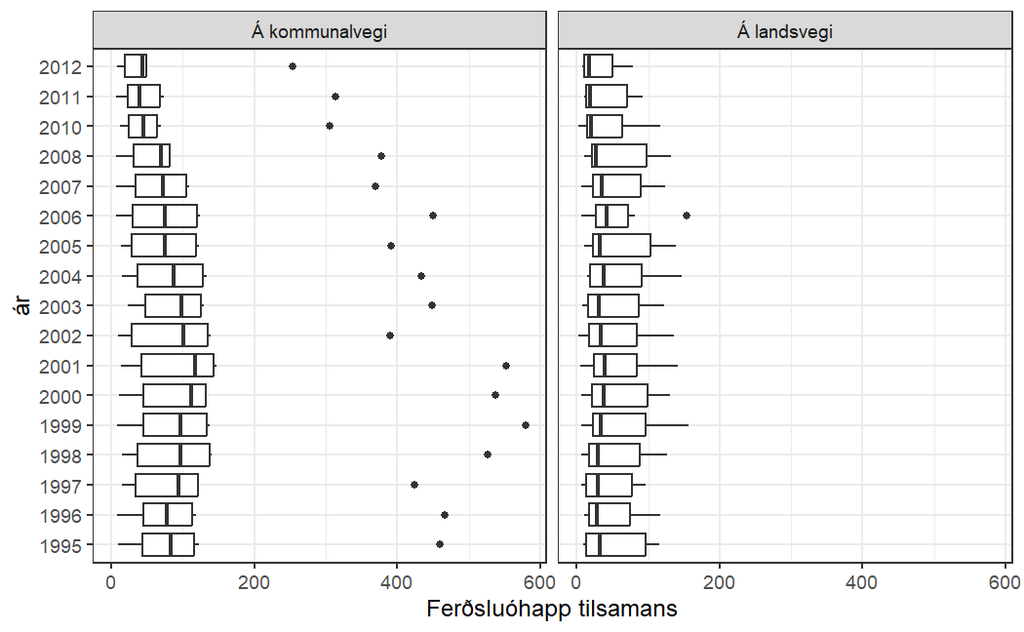

```r
ggplot(data = na.omit(ferdslu_ohapp), mapping = aes(x = `Ferðsluóhapp tilsamans`, y = `ár`)) +
  geom_boxplot()+
  facet_wrap(~stað)
```

```
Vit kunnu observera outliers í hvørjun boxplotti á kommunalvegi frá 1995 til 2012 (uttan 2009),
men harafturímótir kunnu vit bert obsavera ein á landavegi í ár 2006.
Har eru 18 outlighers tilsamans.
```

```r
ferdslu_ohapp %>%
  group_by(sýsla) %>%
   summarise(counts = sum(`Ferðsluóhapp tilsamans` > 150, na.rm = TRUE))
```

| sýsla | counts |
| --- | --- |
| Eysturoyar sýsla | 0 |
| Norðoya sýsla | 0 |
| Sandoyar sýsla | 0 |
| Streymoyar sýsla | 19 |
| Suðuroyar sýsla | 0 |
| Vága sýsla | 0 |

> 3e) her gera vit tvey ymisk plot.

> 3e1) plotta eitt `geom_boxplot()` av `ferdslu_ohapp` við `stað` sum x-aksa, `Ferðsluóhapp tilsamans` sum y-aksa.

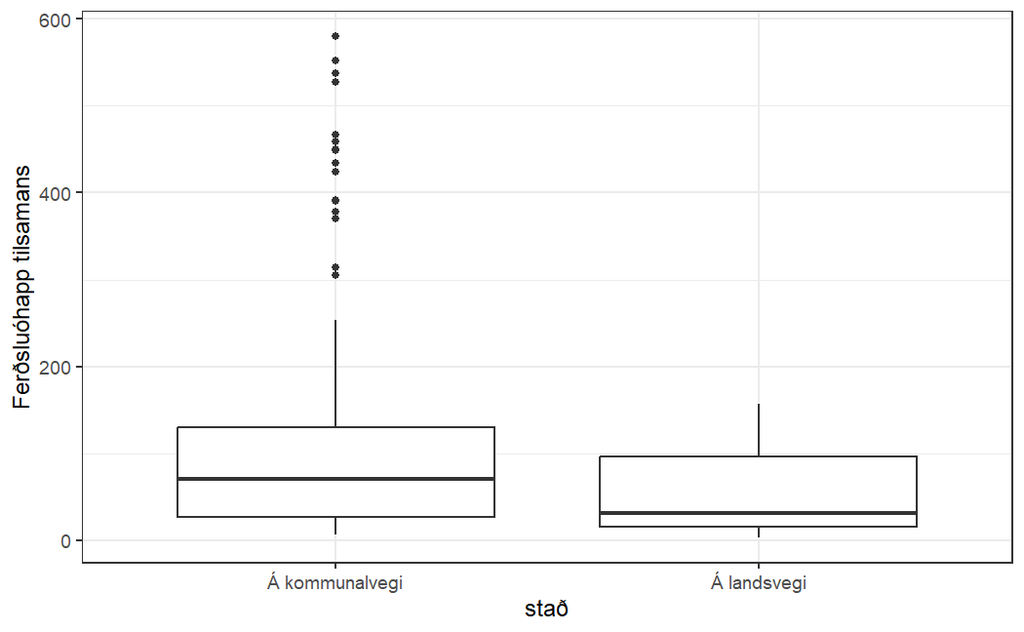

```r
ggplot(data = na.omit(ferdslu_ohapp), mapping = aes(x = `stað`, y = `Ferðsluóhapp tilsamans`)) +
  geom_boxplot()
```

> 3e2) plotta eitt `geom_boxplot()` av `ferdslu_ohapp` við `stað` sum x-aksa, `Ferðsluóhapp tilsamans` sum y-aksa og `sýsla` sum facet-variabul við `scales = "free_y"`. Greið frá hvat tit leggja merki til í hesum plotti, samanborið við plottið í 3e1.

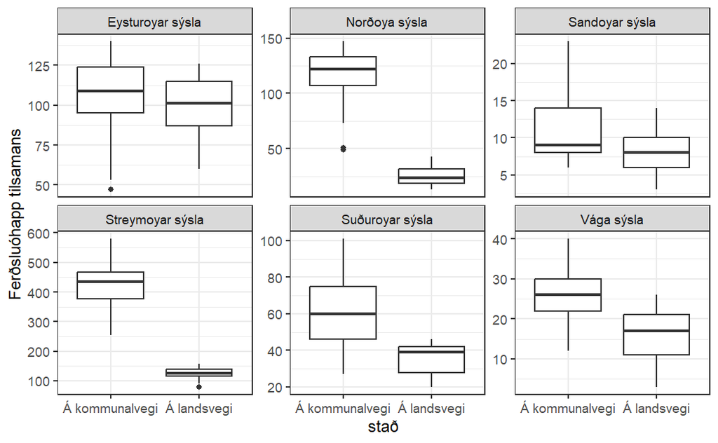

```r
ggplot(data = na.omit(ferdslu_ohapp), mapping = aes(x = `stað`, y = `Ferðsluóhapp tilsamans`)) +
  geom_boxplot() +
  facet_wrap(~sýsla,scales = "free_y")
```

Samanborið við plottið í 3e1, síggja vit at tali av outliers eru mundani minni, hetta kemur av at flestu outliers vóru frá einari sýsla (Streymoyar sýsla), men nú har vit hava deilt okkara data eftur sýslum eru hesi data ikki longur presenteraði sum bert outliers. Hetta kemur av at Streymoyar sýsla hevur nógv størri virðir innan Ferðsluóhapp tilsamans á kommunalvegi í mun til hinar sýslurnar.

> 3f) ger eitt `geom_bar()` plot av `ferdslu_ohapp` við `ár` sum x-aksa, `Ferðsluóhapp tilsamans` sum y-aksa, har tú brúkar `alpha = 0.25`. Hetta vísir samlaða talið av óhappum fyri hvørt árið. Í sama plotti, ger eitt `geom_point()` plot av `ferdslu_ohapp` við `ár` sum x-aksa, `Ferðsluóhapp tilsamans` sum y-aksa, har tú mappar lit av punktum til variabul `stað` og brúkar `sýsla` sum facet-variabul við `scales = "free_y"`. Greið frá hvat tit leggja merki til í hesum plotti.

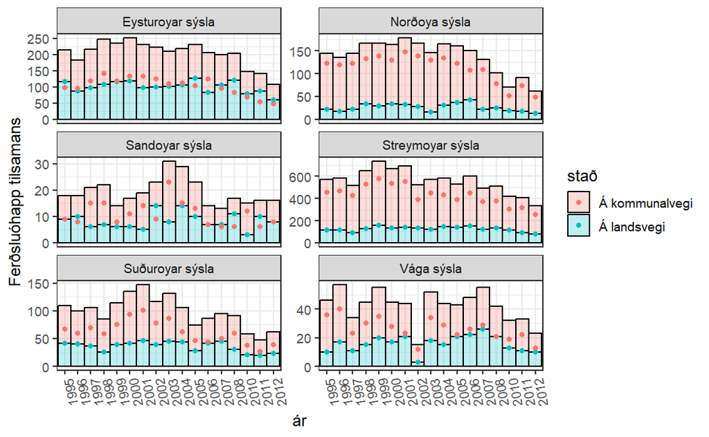

```r
ggplot(data = na.omit(ferdslu_ohapp), mapping = aes(x = `ár`, y = `Ferðsluóhapp tilsamans`, fill =`stað` )) +
  geom_bar(stat="identity", color = "black", alpha = 0.25, width = 1) +
  geom_point(aes(color =`stað`))+
  facet_wrap(~sýsla, ncol = 2, scales = "free_y")+
  theme(axis.text.x = element_text(angle = 100))
```

[output not shown]

### Uppg. 4

> 4a) plotta eitt `geom_boxplot()` av `ferdslu_ohapp` við `Skadd fólk` sum x-aksa, `ár` sum y-aksa og `stað` sum facet-variabul.

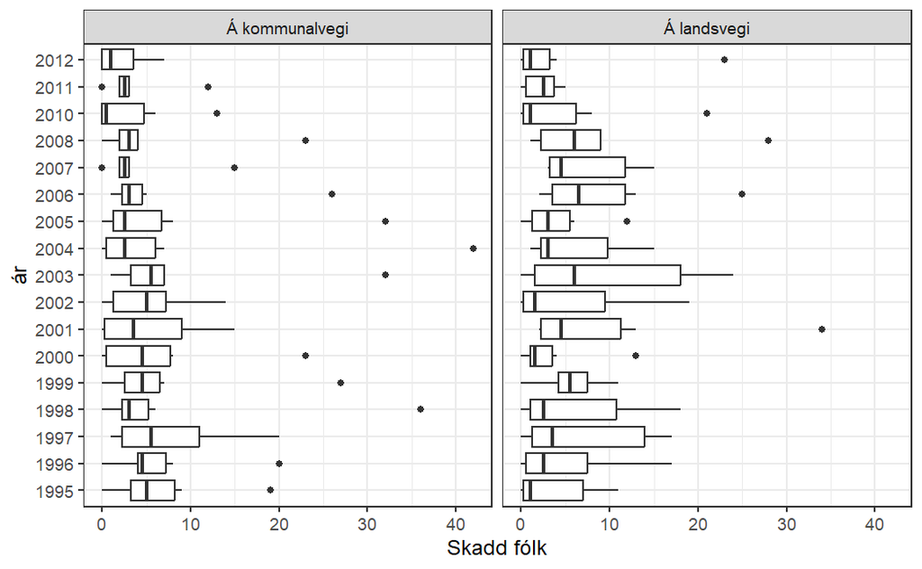

```r
ggplot(data = na.omit(ferdslu_ohapp), aes(x = `Skadd fólk`, y = `ár`)) +
  geom_boxplot() +
  facet_wrap(~`stað`)
```

> 4b) plotta eitt `geom_boxplot()` av `ferdslu_ohapp` við `stað` sum x-aksa, `Skadd fólk` sum y-aksa.

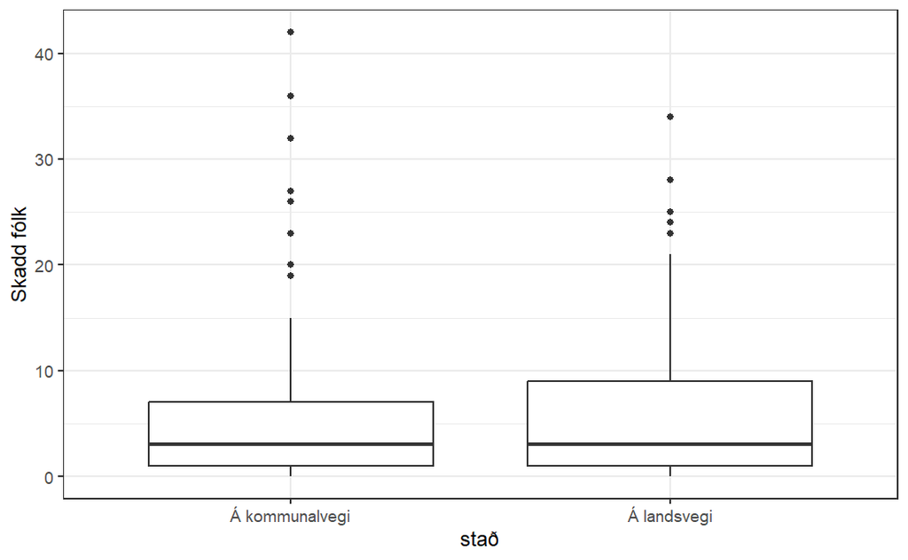

```r
ggplot(data = na.omit(ferdslu_ohapp), aes(x = `stað`, y = `Skadd fólk`)) +
  geom_boxplot()
```

> 4c) plotta eitt `geom_boxplot()` av `ferdslu_ohapp` við `stað` sum x-aksa, `Skadd fólk` sum y-aksa og `sýsla` sum facet-variabul við `scales = "free_y"`.

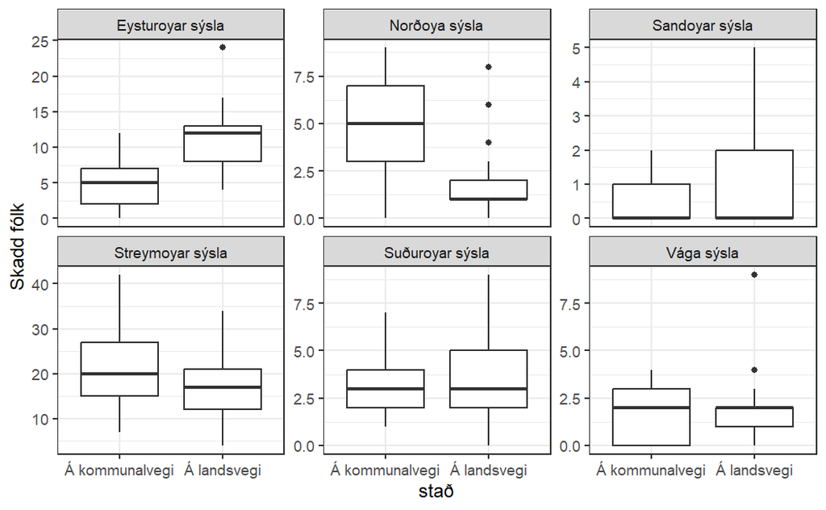

```r
ggplot(data = na.omit(ferdslu_ohapp), aes(x = `stað`, y = `Skadd fólk`)) +
  geom_boxplot() +
  facet_wrap(~ `sýsla`, scales = "free_y")
```

> 4d) plotta eitt `geom_boxplot()` av `ferdslu_ohapp` við `stað` sum x-aksa, lutfallið `Skadd fólk`/`Ferðsluóhapp tilsamans` sum y-aksa og `sýsla` sum facet-variabul við `scales = "free_y"`. Greið frá hvat tit leggja merki til í hesum plotti.

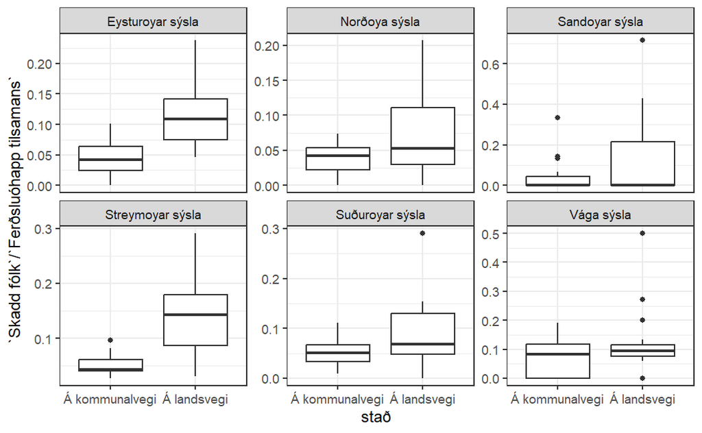

```r
ggplot(data = na.omit(ferdslu_ohapp), aes(x = `stað`, y = `Skadd fólk`/`Ferðsluóhapp tilsamans`)) +
  geom_boxplot() +
  facet_wrap(~ `sýsla`, scales = "free_y")
```

[output not shown]

> 4e) plotta eitt `geom_boxplot()` av `ferdslu_ohapp` við `Skadd fólk`/`Ferðsluóhapp tilsamans` sum x-aksa, `stað` sum y-aksa uttan at brúka nakran facet-variabul. Í sama plotti, legg eitt tilsvarandi `geom_violin()` plot, har tú brúkar `alpha = 0.25`. Í sama plotti, legg harumframt eitt eyka `geom_boxplot()` við `Skadd fólk`/`Ferðsluóhapp tilsamans` sum x-aksa, `Í Føroyum` sum y-aksa, og eitt tilsvarandi `geom_violin()` plot, har tú aftur brúkar `alpha = 0.25`. Greið frá hvat tú leggur merki til í hesum plotti (tip: samanber tey trý box- og violinplottini).

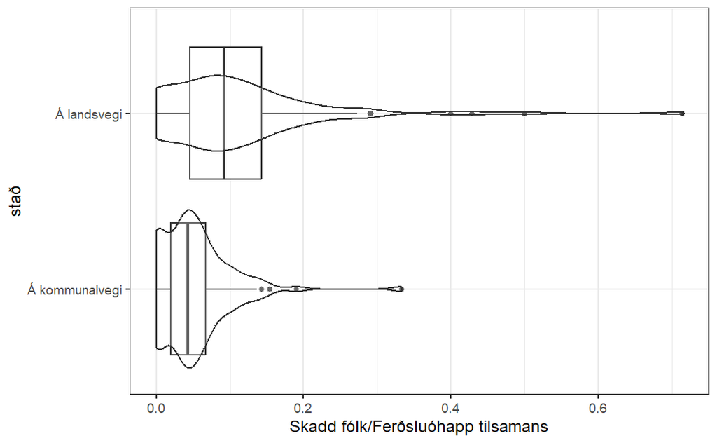

```r
ggplot(data = na.omit(ferdslu_ohapp), aes(x = `Skadd fólk`/`Ferðsluóhapp tilsamans`, y = `stað`)) +
  geom_boxplot() +
  geom_violin(alpha = 0.25) +
  labs(x = "Skadd fólk/Ferðsluóhapp tilsamans", y = "stað")
```

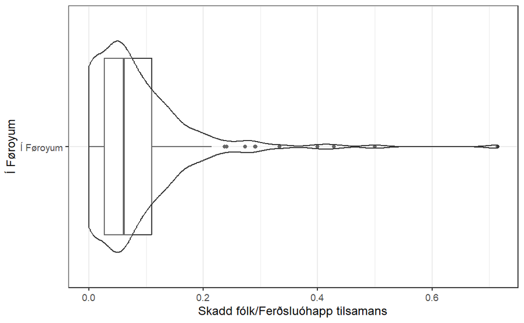

```r
ggplot(data = na.omit(ferdslu_ohapp), aes(x = `Skadd fólk`/`Ferðsluóhapp tilsamans`, y = "Í Føroyum")) +
  geom_boxplot() +
  geom_violin(alpha = 0.25) +
  labs(x = "Skadd fólk/Ferðsluóhapp tilsamans", y = "Í Føroyum")
```

> 4f) ger eina pipe av `ferdslu_ohapp` har tú ikki tekur árið `2009` við, síðani bólkar uppá `stað`, telur antal datapunkt `n` og roknar tal av óhappum `n_ohapp`, tal av skaddum `n_skadd` og roknar sannlíkindini `p_skadd` fyri fólkaskaða. Goym úrslitið í `ohapp_yvirlit` og les hana út (tip: tú fært eina `2 x 5` tibble).

```r
ohapp_yvirlit <- ferdslu_ohapp %>%
  filter(ár != 2009) %>%
  group_by(stað) %>%
  summarize(n = n(),
            n_ohapp = sum(`Ferðsluóhapp tilsamans`, na.rm = TRUE),
            n_skadd = sum(`Skadd fólk`, na.rm = TRUE),
            p_skadd = mean(n_skadd/n_ohapp))

ohapp_yvirlit
```

| stað | n | n_ohapp | n_skadd | p_skadd |
| --- | --- | --- | --- | --- |
| Á kommunalvegi | 102 | 12623 | 636 | 0.05038422 |
| Á landsvegi | 102 | 5285 | 626 | 0.11844844 |

### Uppg. 5

> 5a) ger eitt 95% confidensinterval fyri `p_skadd` í 4f fyri `stað`, ávikavist `Á kommunalvegi, Á landsvegi`.

```r
Broom::glance(t.test(ohapp_yvirlit$p_skadd, conf.level = .95))
```

[output not shown]

> 5b) á netinum kann lesast: “According to the National Highway Traffic Safety Administration (NHTSA), in the United States, the overall probability of being injured in a motor vehicle crash in 2019 was approximately 1 in 103. However, this is a general statistic that includes all types of motor vehicle crashes, from minor fender-benders to more severe accidents.” Ger eina hypotesu-test, sum eftirkannar um tilsvarandi sannlíkindini `Á kommunalvegi` eru tey somu í Føroyum?

> 5c) ger eina `prop.test()` við hóskandi data frá `ophapp_yvirlit` í 4f, sum kannar null-hypotesuna um `p_skadd` er eins fyri teir tveir bólkarnar av `stað`. Hvørja niðurstøðu kemur testin fram til?

> 5d) ger eina pipe av `ferdslu_ohapp` har tú bert tekur ár `1998` og stað `Á landsvegi` við, síðani bólkar uppá `stað, ár, sýsla` (so hesi lesast út), roknar tal av óhappum `n_ohapp` og tal av skaddum `n_skadd`. Goym úrslitið í `landsvegi_ar` og les hana út (tip: tú fært eina `6 x 5` tibble).

> 5e) antak at á landsvegi í Føroyum eru fólkaskaðatilburðir í hvørjari sýslu binomialfordeildir við somu sannlíkindum sum fyri alt landið (`p_skadd = 626/5285`), og plotta tær seks binomialfordeilingarnar svarandi til tey seks `n_ohapp` virðini í `landsvegi_ar`. Greið frá hvat tú leggur merki til í hesum sannlíkinda-plottum (tip: brúka til dømis ein for-loop og eitt facet-plot, eins og vit áður hava gjørt í undirvísingini, og lat `x = seq(0, 25, 1)`).

> 5f)

> 5f1) ger eina pipe av `ferdslu_ohapp` har tú ikki tekur árið `2009` við, síðani bólkar uppá `sýsla`, roknar tal av óhappum `n_ohapp`, tal av skaddum `n_skadd` og talið av ikki-skaddum `n_oskadd = n_ohapp - n_skadd`. Goym úrslitið í `sysla_yvirlit` og les hana út (tip: tú fært eina `6 x 4` tibble).

> 5f2) vel bert variablar `n_skadd, n_oskadd` frá `sysla_yvirlit`. Goym úrslitið í tibble `skadd_oskadd`, og les hana út (tip: tú fært eina `6 x 2` tibble).

> 5f3) brúka `chisq.test()` at kanna null-hypotesuna um at sannlíkindini fyri fólkaskaða í ferðsluóhappum í Føroyum eru óheftir av `sýslu`. Hvørja niðurstøðu kemur testin fram til?

> 5f4) ger eina líknandi test við `prop.test()`, sum kannar null-hypotesuna um at `p_skadd` er eins fyri allar sýslur. Hvørja niðurstøðu kemur testin fram til?